# U3_RStudio

JOSE LUIS VERDE 19130002 Hacemos load del dataset y mostramos los primeros 6 datos para validar que se cargo correctamente.

```r
pokemon <- read.csv("C:\\Users\\verde\\Documents\\AGO2022\\BIGDATA\\pokemon2020\\pokedex_Ver9.csv")
head(pokemon)
```

|  | No | Original_Name | Name | Generation | Height | Weight | Type1 | Type2 | Ability1 | Ability2 | Ability_Hidden | Color | Gender_Male | Gender_Female | Gender_Unknown | Egg_Steps | Egg_Group1 | Egg_Group2 | Capture_Rate | Base_EXP | Final_EXP | Category | Mega_Evolution._Flag | Region_Forme | HP | Attack | Defense | SP_Attack | SP_Defense | … |
| --- | --- | --- | --- | --- | --- | --- | --- | --- | --- | --- | --- | --- | --- | --- | --- | --- | --- | --- | --- | --- | --- | --- | --- | --- | --- | --- | --- | --- | --- | --- |
| 1 | 1 | Bulbasaur | Bulbasaur | 1 | 0.7m | 6.9kg | Grass | Poison | Overgrow |  | Chlorophyll | Green | 87.5 | 12.5 | 0 | 20 | Monster | Grass | 45 | 64 | 1058960 | Ordinary |  |  | 45 | 49 | 49 | 65 | 65 | … |
| 2 | 2 | Ivysaur | Ivysaur | 1 | 1.0m | 13.0kg | Grass | Poison | Overgrow |  | Chlorophyll | Green | 87.5 | 12.5 | 0 | 20 | Monster | Grass | 45 | 142 | 1058960 | Ordinary |  |  | 60 | 62 | 63 | 80 | 80 | … |
| 3 | 3 | Venusaur | Venusaur | 1 | 2.0m | 100.0kg | Grass | Poison | Overgrow |  | Chlorophyll | Green | 87.5 | 12.5 | 0 | 20 | Monster | Grass | 45 | 263 | 1058960 | Ordinary |  |  | 80 | 82 | 83 | 100 | 100 | … |
| 4 | 3 | Venusaur | Venusaur(Mega EV) | 1 | 2.4m | 155.5kg | Grass | Poison | Thick Fat |  |  | Green | 87.5 | 12.5 | 0 | 20 | Monster | Grass | 45 | 281 | 1058960 | Ordinary | Mega |  | 80 | 100 | 123 | 122 | 120 | … |
| 5 | 4 | Charmander | Charmander | 1 | 0.6m | 8.5kg | Fire |  | Blaze |  | Solar Power | Red | 87.5 | 12.5 | 0 | 20 | Monster | Dragon | 45 | 62 | 1058960 | Ordinary |  |  | 39 | 52 | 43 | 60 | 50 | … |
| 6 | 5 | Charmeleon | Charmeleon | 1 | 1.1m | 19.0kg | Fire |  | Blaze |  | Solar Power | Red | 87.5 | 12.5 | 0 | 20 | Monster | Dragon | 45 | 142 | 1058960 | Ordinary |  |  | 58 | 64 | 58 | 80 | 65 | … |

al hacer uso de [] podemos mostrar la linea deseada

```r
pokemon[1,]
```

|  | No | Original_Name | Name | Generation | Height | Weight | Type1 | Type2 | Ability1 | Ability2 | Ability_Hidden | Color | Gender_Male | Gender_Female | Gender_Unknown | Egg_Steps | Egg_Group1 | Egg_Group2 | Capture_Rate | Base_EXP | Final_EXP | Category | Mega_Evolution._Flag | Region_Forme | HP | Attack | Defense | SP_Attack | SP_Defense | … |
| --- | --- | --- | --- | --- | --- | --- | --- | --- | --- | --- | --- | --- | --- | --- | --- | --- | --- | --- | --- | --- | --- | --- | --- | --- | --- | --- | --- | --- | --- | --- |
| 1 | 1 | Bulbasaur | Bulbasaur | 1 | 0.7m | 6.9kg | Grass | Poison | Overgrow |  | Chlorophyll | Green | 87.5 | 12.5 | 0 | 20 | Monster | Grass | 45 | 64 | 1058960 | Ordinary |  |  | 45 | 49 | 49 | 65 | 65 | … |

Ahora usando str podemos ver la estructura del dataset

```r
str(pokemon)
```

[output not shown]

[output cut: 23 more lines]

Primero hacemos load del dataset con el argumento de StringAsFactor para evitar errores de lectura. Con este comando se pueden cambiar datos del dataset, en este ejemplo cambiamos los tipo fire por grass

```r
pokemonstr <- read.csv(file = "C:\\Users\\verde\\Documents\\AGO2022\\BIGDATA\\pokemon2020\\pokedex_Ver9.csv",stringsAsFactors = FALSE)
pokemonstr$Type1 <- ifelse(pokemonstr$Type1 == 'Fire','Grass', pokemonstr$Type1)
pokemonstr$Type1
```

```
   [1] "Grass"    "Grass"    "Grass"    "Grass"    "Grass"    "Grass"    "Grass"    "Grass"
   [9] "Grass"    "Water"    "Water"    "Water"    "Water"    "Bug"      "Bug"      "Bug"
  [17] "Bug"      "Bug"      "Bug"      "Bug"      "Normal"   "Normal"   "Normal"   "Normal"
  [25] "Normal"   "Dark"     "Normal"   "Dark"     "Normal"   "Normal"   "Poison"   "Poison"
  [33] "Electric" "Electric" "Electric" "Ground"   "Ice"      "Ground"   "Ice"      "Poison"
  [41] "Poison"   "Poison"   "Poison"   "Poison"   "Poison"   "Fairy"    "Fairy"    "Grass"
  [49] "Ice"      "Grass"    "Ice"      "Normal"   "Normal"   "Poison"   "Poison"   "Grass"
  [57] "Grass"    "Grass"    "Bug"      "Bug"      "Bug"      "Bug"      "Ground"   "Ground"
  [65] "Ground"   "Ground"   "Normal"   "Dark"     "Steel"    "Normal"   "Dark"     "Water"
  [73] "Water"    "Fighting" "Fighting" "Grass"    "Grass"    "Water"    "Water"    "Water"
  [81] "Psychic"  "Psychic"  "Psychic"  "Psychic"  "Fighting" "Fighting" "Fighting" "Grass"
  [89] "Grass"    "Grass"    "Water"    "Water"    "Rock"     "Rock"     "Rock"     "Rock"
  [97] "Rock"     "Rock"     "Psychic"  "Grass"    "Psychic"  "Grass"    "Water"    "Psychic"
 [105] "Water"    "Water"    "Poison"   "Electric" "Electric" "Normal"   "Fighting" "Normal"
 [113] "Normal"   "Water"    "Water"    "Poison"   "Poison"   "Poison"   "Poison"   "Water"
```

[output cut: 111 more lines]

Para remplazar datos en un dataset se utiliza el “comando” ‘<-’

```r
pokemon$Name[1] <- NA
head(pokemon)
```

[output not shown]

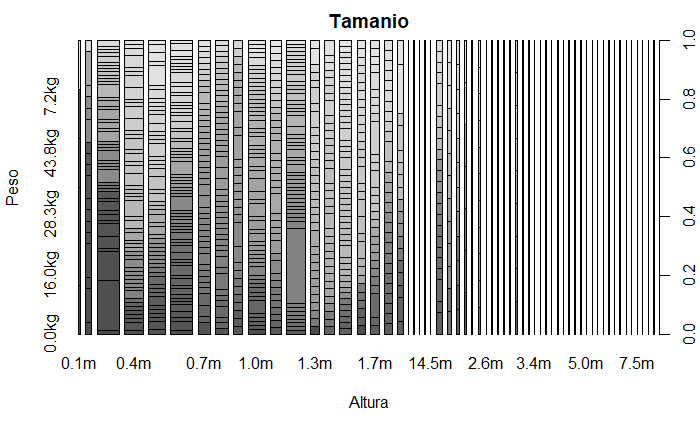

```r
plot(x = pokemon$Height, y = pokemon$Weight, xlab = "Altura", ylab = "Peso", main = "Tamanio")
```

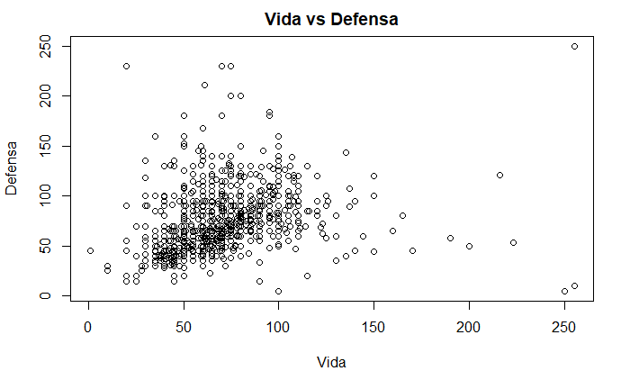

```r
plot(x = pokemon$HP,y = pokemon$Defense, xlab = "Vida", ylab = "Defensa", main = "Vida vs Defensa")
```

Ahora podemos hacer la grafica mas llamativa con los comandos col de color y pch

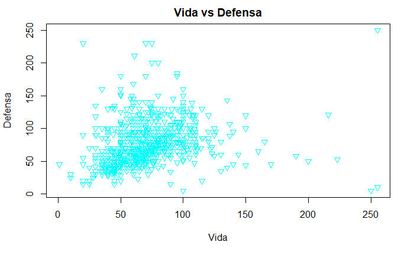

```r
plot(x = pokemon$HP,y = pokemon$Defense, xlab = "Vida", ylab = "Defensa", main = "Vida vs Defensa",
     col = "cyan", pch = 6)
```

Tambien se pueden agregar funciones lineales que se adentren a los datos con la funcion abline.

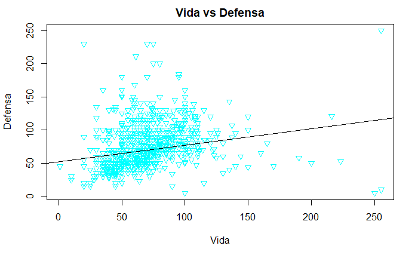

```r
plot(x = pokemon$HP,y = pokemon$Defense, xlab = "Vida", ylab = "Defensa", main = "Vida vs Defensa",
     col = "cyan", pch = 6)
abline(lm(pokemon$HP ~ pokemon$Defense,data = pokemon),col = "black")
```

Como podemos observar los datos no tienden a crecer mucho y se mantienen en un rango promedio de 50 y 120 aprox.

Ahora con barplot podemos hacer una medicion de un solo valor en pokemones selectos, en este caso usare head para mostrar los primeros 6 y muestre su vida base para ver la diferencia.

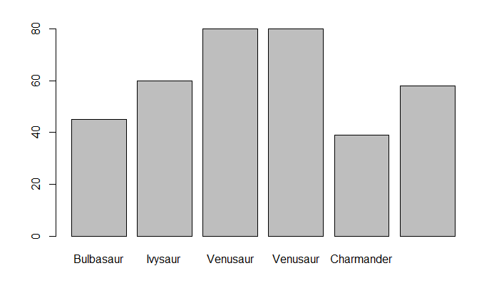

```r
barplot(height = head(pokemon)$HP,names.arg = head(pokemon)$Original_Name)
```

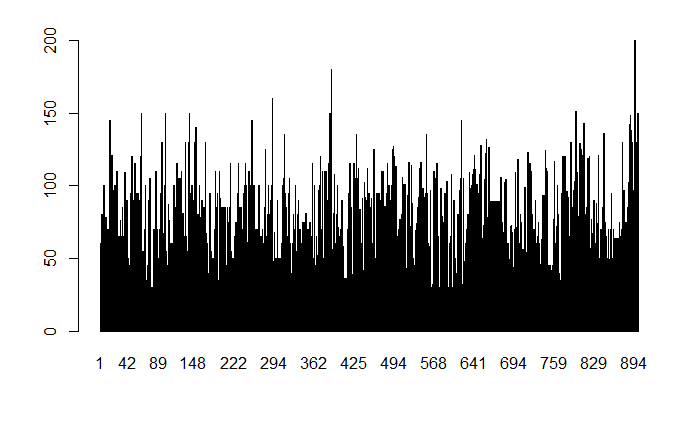

```r
barplot(height = pokemon$Speed,names.arg = pokemon$No)
```

Ahora podemos llamar todos los datos de los pokemon para ver la diferencia de velocidad entre ellos. Ya con estos comandos se entiende la base de R y su potencial, con ellos podemos hacer chequeos de cualquier dato